# Week 2 - Milestone Report

Sam Edwardes

2019-05-08

## Background

The goal of this project is just to display that you’ve gotten used to working with the data and that you are on track to create your prediction algorithm. Please submit a report on R Pubs that explains your exploratory analysis and your goals for the eventual app and algorithm. This document should be concise and explain only the major features of the data you have identified and briefly summarize your plans for creating the prediction algorithm and Shiny app in a way that would be understandable to a non-data scientist manager. You should make use of tables and plots to illustrate important summaries of the data set. The motivation for this project is to:

1. Demonstrate that you’ve downloaded the data and have successfully loaded it in.
2. Create a basic report of summary statistics about the data sets.
3. Report any interesting findings that you amassed so far.

## Part 1 - Loading the data

The data was downloaded from [this link](https://d396qusza40orc.cloudfront.net/dsscapstone/dataset/Coursera-SwiftKey.zip) and unzipped to my local disc. From here the text documents were loaded into r using the libraries *readtext* and *quanteda*. For my analysis, only the english news, twitter, and blog files were used.

```r
news_big <- readtext("data/raw/en_US.news.txt")
blogs_big <- readtext("data/raw/en_US.blogs.txt")
twitter_big <- readtext("data/raw/en_US.twitter.txt")

# read all data
news_big <- readtext("data/raw/en_US.news.txt")
blogs_big <- readtext("data/raw/en_US.blogs.txt")
twitter_big <- readtext("data/raw/en_US.twitter.txt")

# create corpus
news_corp <- corpus(news_big)
blogs_corp <- corpus(blogs_big)
twitter_corp <- corpus(twitter_big)

# segment the corpus to lines
news_corp <- corpus_segment(news_corp, pattern = "\n")
blogs_corp <- corpus_segment(blogs_corp, pattern = "\n")
twitter_corp <- corpus_segment(twitter_corp, pattern = "\n")

# add the source column
docvars(news_corp, "source") <- "news"
docvars(blogs_corp, "source") <- "blog"
docvars(twitter_corp, "source") <- "twitter"

# add all corpus together
all_corp <- news_corp + blogs_corp + twitter_corp

# remove large files from memory
# rm(news_corp, blogs_corp, twitter_corp, news_big, blogs_big, twitter_big)
```

```r
summary(all_corp)
```

```
Corpus consisting of 3336692 documents, showing 100 documents:

               Text Types Tokens Sentences pattern source length
   en_US.news.txt.1    27     33         3      \n   news    153
   en_US.news.txt.2    28     32         2      \n   news    177
   en_US.news.txt.3    69     92         3      \n   news    498
   en_US.news.txt.4    39     45         4      \n   news    246
   en_US.news.txt.5    32     40         1      \n   news    200
   en_US.news.txt.6     4      4         1      \n   news     25
   en_US.news.txt.7    46     55         2      \n   news    272
   en_US.news.txt.8    38     47         1      \n   news    280
   en_US.news.txt.9    28     40         2      \n   news    167
  en_US.news.txt.10    26     29         1      \n   news    177
  en_US.news.txt.11    20     22         1      \n   news    105
  en_US.news.txt.12    25     28         1      \n   news    152
  en_US.news.txt.13    57     82         4      \n   news    377
  en_US.news.txt.14    35     45         3      \n   news    202
  en_US.news.txt.15    28     34         1      \n   news    164
  en_US.news.txt.16    10     11         1      \n   news     38
  en_US.news.txt.17    19     23         1      \n   news    109
  en_US.news.txt.18    15     15         1      \n   news     95
  en_US.news.txt.19    65     98         7      \n   news    530
  en_US.news.txt.20    17     18         1      \n   news     87
  en_US.news.txt.21    26     33         3      \n   news    147
  en_US.news.txt.22    23     32         1      \n   news    131
  en_US.news.txt.23    26     31         2      \n   news    146
  en_US.news.txt.24    34     40         2      \n   news    197
  en_US.news.txt.25    40     44         2      \n   news    234
  en_US.news.txt.26    30     32         2      \n   news    154
  en_US.news.txt.27    42     53         3      \n   news    278
  en_US.news.txt.28     7      7         1      \n   news     16
  en_US.news.txt.29    38     42         1      \n   news    225
  en_US.news.txt.30    41     47         1      \n   news    231
  en_US.news.txt.31    99    159         9      \n   news    982
  en_US.news.txt.32    34     48         3      \n   news    206
  en_US.news.txt.33    13     13         1      \n   news     70
  en_US.news.txt.34     4      4         1      \n   news     17
  en_US.news.txt.35    42     51         2      \n   news    284
  en_US.news.txt.36    42     54         3      \n   news    270
  en_US.news.txt.37    43     51         2      \n   news    318
```

[output cut: 52 more lines]

```
  en_US.news.txt.90     1      1         1      \n   news      8
  en_US.news.txt.91    58     80         4      \n   news    406
  en_US.news.txt.92    26     30         1      \n   news    195
  en_US.news.txt.93    25     26         1      \n   news    137
  en_US.news.txt.94     6      6         1      \n   news     21
  en_US.news.txt.95    32     41         3      \n   news    175
  en_US.news.txt.96    48     63         4      \n   news    307
  en_US.news.txt.97    15     21         1      \n   news     81
  en_US.news.txt.98    54     77         4      \n   news    320
  en_US.news.txt.99     1      2         1      \n   news     11
 en_US.news.txt.100    22     23         1      \n   news    111

Source: Combination of corpuses news_corp + blogs_corp and twitter_corp
Created: Mon Aug 05 08:55:19 2019
Notes: corpus_segment.corpus(news_corp, pattern = "\n") corpus_segment.corpus(blogs_corp, pattern = "\n") corpus_segment.corpus(twitter_corp, pattern = "\n")
```

## Part 2 - Summary statistics

Lets review some summaries of the data data we have loaded into R.

There are exactly 3336692 text documents that have been loaded. The breakdown of these documents between the three sources of news, blog, and twitter is as follows:

```r
table((all_corp$documents)[,"source"])
```

```
   blog    news twitter
 899287   77258 2360147
```

The general trend of text length (number of characters is as follows):

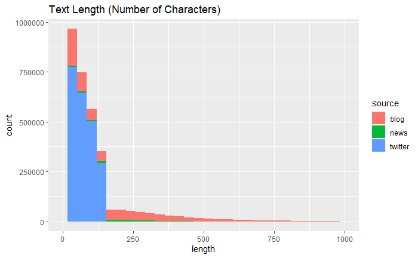

```r
ggplot(all_corp$documents, aes(x = length, fill = source)) +
    geom_histogram() +
    xlim(0, 1000) +
    ggtitle("Text Length (Number of Characters)")
```

```r
NA
```

We are also interested to see what words appear with the most frequency. To accomplish this, we will tokenize the data, then create a data feature matrix (dfm) to see which words occur most frequently.

*A sample of the corpus was used in order to speed up the analysis.*

```r
# set seed
set.seed(1993)

# select a corpus sample
sample_corp <- corpus_sample(all_corp, size = 500000)

# tokenize the documents
sample_tokens <- tokens(sample_corp, remove_numbers = TRUE, remove_punct = TRUE)
sample_tokens <- tokens_tolower(sample_tokens)

# create a dfm
sample_dfm <- dfm(sample_tokens)

# summarise the top n words
topfeatures(sample_dfm, 100)
```

```
   the     to    and      a      i     of     in    you     is    for   that     it     on     my
438862 287203 239168 236121 225107 193759 153410 127083 121482 115690 107245 106929  85966  84705
  with   this    was     be   have     at    are    but     me     so     we     as    not      â
 71507  64872  61873  61169  59487  56007  54115  51391  50980  49573  48957  46216  45975  44768
  your    all   just   from    out   what     up   like     or     he     if   they   will  about
 41029  40378  38402  36631  34285  33759  33593  33567  33192  33187  32724  32576  32346  32004
   one     do      s    can   when     by    get     an    i'm   time   more  there    his    had
 31525  29900  29814  28828  28643  28554  27931  27761  25144  24894  24187  23710  23386  23246
  some   good    our   love     no    has    who    how    now    day    her   know  would   it's
 23236  22561  22481  22448  22379  22308  21891  21635  21627  21289  21275  21090  20677  19355
   new   been    she  their   them    see     go people   were   back  great      t  don't  think
 19341  19021  18788  18760  18102  17776  17465  16979  16505  16428  16176  15590  15540  15432
    us   make  today    too thanks really  going   much   then   only     am    got     rt  which
 15043  15002  14628  14591  14537  14522  14498  14451  14214  13884  13549  13353  13258  13177
  into   than
 13149  13042
```

Part 3 - Interesting observations

One of the most frequently occurring words was **“â”**. In order to understand how this word should be treated, we should understand how it was used in context. Lets find an example of this word in action.

```r
# View 5 examples
head(kwic(sample_tokens, "â"),5)
```

| [en_US.blogs.txt.313856, 1] |  | \| | â | \| | œwill they find your fingerprints |
| --- | --- | --- | --- | --- | --- |
| [en_US.blogs.txt.313856, 10] | your fingerprints on a knife | \| | â | \| |  |
| [en_US.blogs.txt.307694, 63] | nobody believes that he reformed | \| | â | \| | œokay now iâ ve took |
| [en_US.blogs.txt.307694, 94] | normal urobuchi from now on | \| | â | \| |  |
| [en_US.twitter.txt.520332, 1] |  | \| | â | \| | œ my prayers are with |

```r
# lets look at a specific example from blogs and twitter
texts(sample_corp)["en_US.twitter.txt.1239564"]
```

[output not shown]

```r
texts(sample_corp)["en_US.twitter.txt.2014655"]
```

[output not shown]

As can be seen, this symbol does not appear to have a lot of meaning. It is likely to do with HTML formatting. When we build our model we will considering removing this symbol, or replacing with with something else.

Another frequently occurring token was **rt**. Let’s look at this token in context as well.

```r
# View 5 examples
head(kwic(sample_tokens, "rt"),5)
```

| [en_US.twitter.txt.1239564, 3] | you right | \| | rt | \| | people let me down but |
| --- | --- | --- | --- | --- | --- |
| [en_US.twitter.txt.2205456, 11] | a free lg pizza today | \| | rt | \| | this add something u wanna |
| [en_US.twitter.txt.2014655, 5] | we love you too | \| | rt | \| | i love you guys your |
| [en_US.twitter.txt.570869, 1] |  | \| | rt | \| | margaret montoya longtime university of |
| [en_US.twitter.txt.590611, 13] | out but they defend it | \| | rt | \| | what are your thoughts about |

```r
# lets look at a specific example from blogs and twitter
texts(sample_corp)["en_US.twitter.txt.2014655"]
```

```
                                                                     en_US.twitter.txt.2014655
"We love you too! RT : I love you guys! Your bands ROCK! And it's the best on town! Kick ass!"
```

```r
texts(sample_corp)["en_US.twitter.txt.2205456"]
```

```
                                                                                                            en_US.twitter.txt.2205456
"Time's running out to win a free lg pizza today! RT this & add something u wanna do this fall. We'll randomly select a winner at 5."
```

Similar to the last example, “RT” doesn’t seem to have a lot of meaning or value in predicting the next word. It likely refers to a “re-tweet” in twitter. When building our model we will consider removing the token RT.